# Limpieza general de una base de datos

03-08-2023

## INTRODUCCIÓN

La **limpieza de datos** (en inglés data cleansing o data scrubbing) es el acto de descubrimiento y corrección o eliminación de registros de datos erróneos de una tabla o base de datos. El proceso de limpieza de datos permite identificar datos incompletos, incorrectos, inexactos, no pertinentes, etc. y luego substituir, modificar o eliminar estos datos sucios (“data duty”). Después de la limpieza, la base de datos podrá ser compatible con otras bases de datos similares en el sistema.

[figure not shown]

## INTRODUCCIÓN

### ¿Por qué es importante la limpieza de datos?

La depuración de datos es vital para garantizar una alta integridad de la información en cualquier investigación. Mientras más confiable sea la data, mejor serán las decisiones que tomes con base en ella. Los datos de calidad pueden variar dependiendo de cuál sea su cualidad, entre las principales se encuentran:

| Calidad | Descripción |
| --- | --- |
| Exactitud | Todos los datos deben ser precisos. Una forma de comprobar su exactitud es comparándolos con otras fuentes. |
| Coherencia | La coherencia de los datos permite saber si el dato sobre un objeto o persona es la misma en diferentes BD. |
| Validez | Todos los datos deben cumplir con reglas o restricciones definidas. Por ejemplo: formato adecuado, no duplicados, no vacíos, etc. |
| Uniformidad | Es importante que todos los datos dentro de las BD tengan los mismos valores o unidades. |

## CRITERIOS PARA LA LIMPIEZA

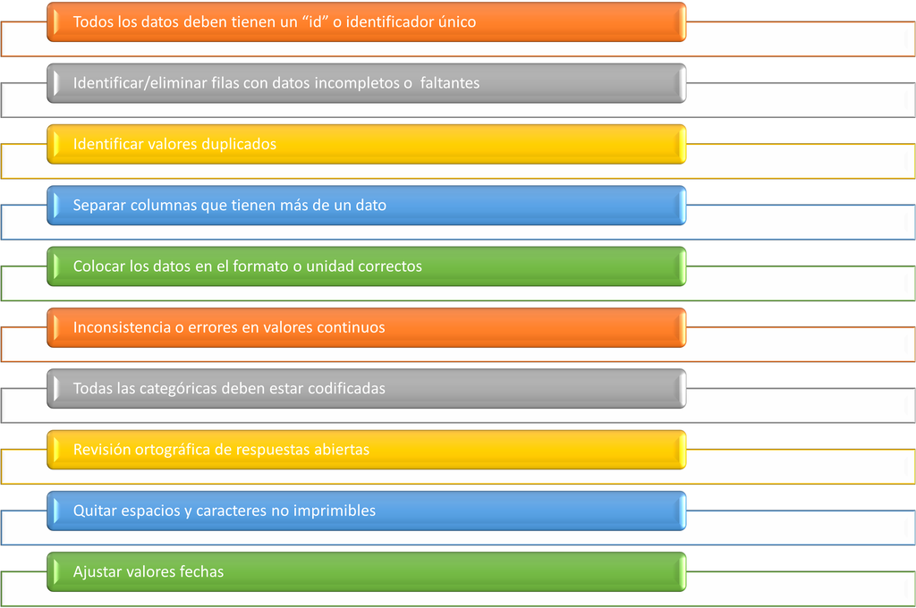

## Aspectos básicos a considerar

- La función head() y la función tail() son usadas frecuentemente para ver las primeras y últimas filas de nuestra base de datos. Nosotros en este curso usamos mayormente el head().
- La función str() nos permite dar un vistazo rápido a la estructura de nuestra base de datos.
- Operadores booleanos: TRUE, FALSE. Permiten describir relaciones lógicas entre los datos.
- Seleccion de datos por notación matricial:
  - data_set[0, ] #obtengo la primera fila (el encabezado)
  - data_set[2:5, ] #se obtiene desde la fila 2 a la fila 5
  - data_set[, 1] #obtengo la primera columna (variable)
  - data_set[, 1:5] #se obtiene desde la columna 1 a la 5
  - data_set[, c(1,3,5,8)] #se obtienen columnas específicas
  - data_set[data_set$broadperiod == “EARLY MEDIEVAL”, ] #muestra los datos que tienen coincidencia con “EARLY MEDIEVAL” de la columna broadperiod

## Aspectos básicos a considerar… continuación

**Condicionales if**

Es usado cuando deseamos que una operación se ejecute únicamente cuando una condición se cumple.

```r
if(4 > 3) {
  "Verdadero"    # Se cumple la condición y se muestra "verdadero"
}
```

Por su parte el “else” se usa para complementar al if. Indica qué ocurrirá cuando la condición no se cumple

```r
if(4 > 5) {
  "Verdadero"
} else {
  "Falso"   # No se cumple la condición y se muestra "Falso"
}
```

Si usamos el “if” para recorrer un vector, ocurrirá esto:

```r
if(1:10 < 3) {
  "Verdadero"
}
```

Nos da un mensaje nos dice que sólo se usará el primer elemento del vector para evaluar si la condición es verdadera y lo demás será ignorado.

## Aspectos básicos a considerar… continuación

Para corregir esto, usamos el ifelse(), que se usa para recorrer un vector según una condición.

```r
ifelse(1:10 < 3, TRUE, FALSE)
```

```
 [1]  TRUE  TRUE FALSE FALSE FALSE FALSE FALSE FALSE FALSE FALSE
```

Función table(). sirve para para representar los datos de forma categórica en forma de tabla ya sea de una o dos vías Por ejemplo:

```r
mi_primer_dataframe <- data.frame(
  "sexo_a"=c("fem", "mas",  "fem",  "mas",  "mas",  "fem"),
  "edad_a"=c(30, 18, 20, 21, 20, 30),
  "Long_max_hum"=c(289, 295.5, 290.2, 292,  298, 284.8),
  "Diam_ver_cab_hum"=c(15.4, 14.5, 16.2, 15.9,  16.6, 14.8),
  "Diam_hor_cab_hum"=c(14.6, 13.5, 16,  14.3, 16, 14.2))
table(mi_primer_dataframe$sexo_a)   #ejemplo de una tabla de frecuencia de un vía
```

```
fem mas
  3   3
```

[figure not shown]

## Todos los datos deben tienen un “id”

Cargamos la librería readxl con library() | Previamente debemos instalarla

```r
#install.packages("readxl")
library(readxl)
```

Importamos el fichero de excel

```r
data_set<-read_excel("data/data_limpeza.xlsx", sheet="Hoja1")
```

Hacemos un preview de la base con un head() y nos ayudamos con kableExtra.

```r
#install.packages("kableExtra")  #Instalamos este paquete para ayudarnos a mejorar tablas
library(kableExtra)              #Cargamos la librería, Revisar documentación
head(data_set) %>% kbl() %>% kable_classic_2(full_width = F, position = "left")
```

| ID | GENERO | EDAD | NIV_EDUC | E_CIVIL | CIUDAD | Fecha_nac | Peso | Talla |
| --- | --- | --- | --- | --- | --- | --- | --- | --- |
| 1 | M | 39 | MED | CAS | BIOBIO,LOSANGELES | 30736 | 73 | 171 |
| 2 | F | 49 | MED | VIU | METROPOLITANA,SANTIAGO | 27088 | 70 | 173 |
| 3 | M | 39 | TEC | CAS | ANTOFAGASTA,ANTOFAGASTA | 30771 | 57 | 164 |
| 4 | F | 36 | UNV | CAS | METROPOLITANA,SANTIAGO | 31929 | 59 | 173 |
| 5 | M | 44 | TEC | CAS | METROPOLITANA,SANTIAGO | 28981 | 1100 | 184 |
| 6 | M | 40 | TEC | CAS | METROPOLITANA,SANTIAGO | 30623 | 57 | 164 |

## Todos los datos… continuación

Aunque esta base ya tiene un ID, vamos a crear otro desde cero, lo llamaremos ID2

```r
#Primeros contamos la cantidad de filas y lo asignamos a un objeto
n <- nrow(data_set)
cat("La Base tiene: ", n, " filas")
```

```
La Base tiene:  120  filas
```

```r
#Creamos una nueva variable en la base y le generamos una secuencia de numeros del 1 al 120
data_set$ID2 <- seq(from=1, to=n, by=1)
head(data_set,8) %>% kbl() %>% kable_classic_2(full_width = F, position = "left")
```

| ID | GENERO | EDAD | NIV_EDUC | E_CIVIL | CIUDAD | Fecha_nac | Peso | Talla | ID2 |
| --- | --- | --- | --- | --- | --- | --- | --- | --- | --- |
| 1 | M | 39 | MED | CAS | BIOBIO,LOSANGELES | 30736 | 73 | 171 | 1 |
| 2 | F | 49 | MED | VIU | METROPOLITANA,SANTIAGO | 27088 | 70 | 173 | 2 |
| 3 | M | 39 | TEC | CAS | ANTOFAGASTA,ANTOFAGASTA | 30771 | 57 | 164 | 3 |
| 4 | F | 36 | UNV | CAS | METROPOLITANA,SANTIAGO | 31929 | 59 | 173 | 4 |
| 5 | M | 44 | TEC | CAS | METROPOLITANA,SANTIAGO | 28981 | 1100 | 184 | 5 |
| 6 | M | 40 | TEC | CAS | METROPOLITANA,SANTIAGO | 30623 | 57 | 164 | 6 |
| 7 | M | 45 | UNV | CAS | METROPOLITANA,SANTIAGO | 28557 | 59 | 177 | 7 |
| 8 | F | 41 | TEC | SOL | METROPOLITANA,SANTIAGO | 30313 | 54 | 164 | 8 |

## Identificar valores duplicados

Revisamos si en la columna ID original de la base de datos tiene valores repetidos.

```r
duplicated(data_set$ID)  #Los valores true indican que hay repetidos
```

```
  [1] FALSE FALSE FALSE FALSE FALSE FALSE FALSE FALSE FALSE FALSE FALSE FALSE
 [13] FALSE  TRUE FALSE FALSE FALSE FALSE FALSE FALSE FALSE FALSE FALSE FALSE
 [25] FALSE FALSE FALSE FALSE FALSE FALSE FALSE FALSE FALSE FALSE FALSE FALSE
 [37] FALSE FALSE FALSE FALSE FALSE FALSE FALSE FALSE FALSE FALSE FALSE FALSE
 [49] FALSE FALSE FALSE FALSE FALSE FALSE FALSE FALSE FALSE FALSE FALSE FALSE
 [61] FALSE FALSE FALSE FALSE FALSE FALSE FALSE FALSE FALSE FALSE FALSE FALSE
 [73] FALSE FALSE FALSE FALSE  TRUE FALSE FALSE FALSE FALSE FALSE FALSE FALSE
 [85] FALSE FALSE FALSE FALSE FALSE FALSE FALSE FALSE FALSE FALSE FALSE FALSE
 [97] FALSE FALSE  TRUE FALSE FALSE FALSE FALSE FALSE FALSE FALSE FALSE FALSE
[109] FALSE FALSE FALSE FALSE FALSE FALSE FALSE FALSE FALSE FALSE FALSE FALSE
```

```r
duplicados <- duplicated(data_set$ID)  #Los guardamos en un objeto
sum(duplicados==TRUE) #Contamos cuantos TRUE existen
```

```
[1] 3
```

Es decir, hay 3 datos que estan duplicados. Ahora queremos saber quienes son.

## Identificar valores… continuación

```r
data_set[duplicados, ] %>% kbl() %>% kable_classic_2(full_width = F, position = "left")
```

| ID | GENERO | EDAD | NIV_EDUC | E_CIVIL | CIUDAD | Fecha_nac | Peso | Talla | ID2 |
| --- | --- | --- | --- | --- | --- | --- | --- | --- | --- |
| 10 | M | 43 | UNV | CAS | METROPOLITANA,SANTIAGO | 29230 | 65 | 160 | 14 |
| 31 | m | 44 | UNV | CAS | METROPOLITANA,SANTIAGO | 28930 | 44 | 160 | 77 |
| 5 | F | 39 | TEC | SOL | METROPOLITANA,SANTIAGO | 30830 | 74 | 168 | 99 |

```r
#Observamos los valores duplicados
```

Como ya sabemos quienes son, agregamos un indentificador a los valores repetidos por medio de un condicional

```r
data_set$ID <- ifelse(duplicados == TRUE, "999", data_set$ID)
sum(data_set$ID == "999")  #Contamos para verificar los valores repetidos
```

```
[1] 3
```

Como vemos que son las misma cantidad, procedemos a eliminar los valores repetidos

```r
data_set <- data_set[data_set$ID != "999", ]
nrow(data_set) #Volvemos a contar la cantidad de filas de nuestra base para verificar que hubo un cambio
```

```
[1] 117
```

```r
sum(duplicated(data_set$ID) == TRUE) #verificamos que no existan duplicados en ID
```

```
[1] 0
```

## Identificar/eliminar datos faltantes

Lo primero es saber si existen valores perdidos en nuestra base con la función is.na()

```r
sum(is.na(data_set))  #Cuenta todos los valores perdidos en la base
```

```
[1] 23
```

Si queremos conocer los valores perdidos de cada variable, hay que usar una función vectorizada llamada “sapply”. Nos apoyamos con la función kableExtra para visialización

```r
#Aqui vemos los valores perdidos de cada variable.
t(sapply(data_set,function(x) length(which(is.na(x))))) %>% kbl() %>%
  kable_classic_2(full_width = F, position = "center")
```

| ID | GENERO | EDAD | NIV_EDUC | E_CIVIL | CIUDAD | Fecha_nac | Peso | Talla | ID2 |
| --- | --- | --- | --- | --- | --- | --- | --- | --- | --- |
| 0 | 1 | 3 | 13 | 0 | 6 | 0 | 0 | 0 | 0 |

Explicaremos este código parte por parte. La función sapply en R es una función vectorizada que permite iterar sobre una lista o vector sin la necesidad de usar el bucle “for”

```r
for(i in 2:4) {print(i ^ 2)} #Aquí hace un recorrido de cada valor y lo eleva la cuadrado
```

```
[1] 4
[1] 9
[1] 16
```

## Identificar/eliminar datos… continuación

Cuando tenemos una lista o data frame hay que usar la función “length” para que cada columna se convierta en una lista “independiente” y luego se haga el “recorrido” a cada una. Por ejemplo:

```r
#Aqui nos hace el conteo de cada columna de nuestra base
t(sapply(data_set, length)) %>% kbl() %>% kable_classic_2(full_width = F, position = "center")
```

| ID | GENERO | EDAD | NIV_EDUC | E_CIVIL | CIUDAD | Fecha_nac | Peso | Talla | ID2 |
| --- | --- | --- | --- | --- | --- | --- | --- | --- | --- |
| 117 | 117 | 117 | 117 | 117 | 117 | 117 | 117 | 117 | 117 |

Así podemos incorporar la funcionalidad “which” que encuentra los índices de una lista que cumplen con cierta condición, por ejemplo:

```r
which(is.na(data_set))  #Aquí busca los datos(indices) cuyo valor es NA
```

```
 [1] 147 251 337 338 456 457 458 459 460 461 462 463 464 465 466 467 468 615 688
[20] 692 693 699 700
```

Es así que podemos unirlo todo dentro de la función “length”, pero a su vez, dentro de una función en “sapply”. sapply(data_set, function(x) length(which(is.na(x)))). Donde el argumento “x” de la función es sustituido por nuestro data_set y eso es la gracia de la funcionalidad “sapply”.

## Identificar/eliminar datos… continuación

Una vez que ya sabemos cuantos y donde está los datos vacíos o perdidos, los eliminamos con la función na.omit(). Esta función elimina toda la fila donde exista un valor vacío

```r
data_set <- na.omit(data_set)
sum(is.na(data_set))   # Volvemos a revisar si existen datos vacíos.
```

```
[1] 0
```

Al constatar que ya no hay valores vacíos, podemos revisar cuanto es el “n” de cada columna de nuestro data frame. Nos apoyamos con la función kableExtra para que se vea mejor

```r
t(sapply(data_set, length)) %>% kbl() %>% kable_classic_2(full_width = F, position = "center")
```

| ID | GENERO | EDAD | NIV_EDUC | E_CIVIL | CIUDAD | Fecha_nac | Peso | Talla | ID2 |
| --- | --- | --- | --- | --- | --- | --- | --- | --- | --- |
| 100 | 100 | 100 | 100 | 100 | 100 | 100 | 100 | 100 | 100 |

Observamos que ahora nuestra base tiene 100 filas.

## Separar columnas que tienen más de un dato

Para separar columnas que tienen más de un dato usaremos como ejemplo la columna “CIUDAD”, que observamos que tiene el nombre de la Región y la Comuna

```r
head(data_set) %>% kbl() %>% kable_classic_2(full_width = F, position = "left")
```

| ID | GENERO | EDAD | NIV_EDUC | E_CIVIL | CIUDAD | Fecha_nac | Peso | Talla | ID2 |
| --- | --- | --- | --- | --- | --- | --- | --- | --- | --- |
| 1 | M | 39 | MED | CAS | BIOBIO,LOSANGELES | 30736 | 73 | 171 | 1 |
| 2 | F | 49 | MED | VIU | METROPOLITANA,SANTIAGO | 27088 | 70 | 173 | 2 |
| 3 | M | 39 | TEC | CAS | ANTOFAGASTA,ANTOFAGASTA | 30771 | 57 | 164 | 3 |
| 4 | F | 36 | UNV | CAS | METROPOLITANA,SANTIAGO | 31929 | 59 | 173 | 4 |
| 5 | M | 44 | TEC | CAS | METROPOLITANA,SANTIAGO | 28981 | 1100 | 184 | 5 |
| 6 | M | 40 | TEC | CAS | METROPOLITANA,SANTIAGO | 30623 | 57 | 164 | 6 |

Nos damos cuenta que podemos usar la coma(“,”) como separador de las dos instancias Región/Comuna. Para ello podemos usar la función strsplit()

```r
region_ciudad <- strsplit(data_set$CIUDAD, ",") #Usando la "," como separador, genera un lista
```

## Separar columnas que tienen más de … continuación

Convertimos la lista “region_ciudad” a una matriz en dos columnas leido en filas, esto para poder identificar o separar en dos columnas: Regiones y Comunas

```r
m <- matrix(unlist(region_ciudad), ncol = 2, byrow=T)
data_set$Region <- m[,1] #Agregamos la columna 1 a una nueva columna en la base llamada Región
data_set$Comuna <- m[,2] #Agregamos la columna 2 a una nueva columna en la base llamada Ciudad
head(data_set, 16) %>% kbl() %>%
  kable_classic_2(full_width = F, position = "left") %>%
  kable_styling(fixed_thead = T, bootstrap_options = "responsive", font_size = 12) %>%
  row_spec(0, font_size = 12)
```

| ID | GENERO | EDAD | NIV_EDUC | E_CIVIL | CIUDAD | Fecha_nac | Peso | Talla | ID2 | Region | Comuna |
| --- | --- | --- | --- | --- | --- | --- | --- | --- | --- | --- | --- |
| 1 | M | 39 | MED | CAS | BIOBIO,LOSANGELES | 30736 | 73 | 171 | 1 | BIOBIO | LOSANGELES |
| 2 | F | 49 | MED | VIU | METROPOLITANA,SANTIAGO | 27088 | 70 | 173 | 2 | METROPOLITANA | SANTIAGO |
| 3 | M | 39 | TEC | CAS | ANTOFAGASTA,ANTOFAGASTA | 30771 | 57 | 164 | 3 | ANTOFAGASTA | ANTOFAGASTA |
| 4 | F | 36 | UNV | CAS | METROPOLITANA,SANTIAGO | 31929 | 59 | 173 | 4 | METROPOLITANA | SANTIAGO |
| 5 | M | 44 | TEC | CAS | METROPOLITANA,SANTIAGO | 28981 | 1100 | 184 | 5 | METROPOLITANA | SANTIAGO |
| 6 | M | 40 | TEC | CAS | METROPOLITANA,SANTIAGO | 30623 | 57 | 164 | 6 | METROPOLITANA | SANTIAGO |
| 7 | M | 45 | UNV | CAS | METROPOLITANA,SANTIAGO | 28557 | 59 | 177 | 7 | METROPOLITANA | SANTIAGO |
| 8 | F | 41 | TEC | SOL | METROPOLITANA,SANTIAGO | 30313 | 54 | 164 | 8 | METROPOLITANA | SANTIAGO |
| 9 | F | 33 | MED | CAS | ARICA Y PARINACOTA,ARICA | 33159 | 56 | 157 | 9 | ARICA Y PARINACOTA | ARICA |
| 10 | f | 39 | MED | VIU | METROPOLITANA,SANTIAGO | 30955 | 69 | 171 | 10 | METROPOLITANA | SANTIAGO |
| 11 | F | 46 | MED | CAS | METROPOLITANA,SANTIAGO | 28151 | 54 | 161 | 11 | METROPOLITANA | SANTIAGO |
| 12 | F | 37 | TEC | CAS | METROPOLITANA,SANTIAGO | 31722 | 78 | 168 | 12 | METROPOLITANA | SANTIAGO |
| 13 | M | 48 | UNV | CAS | METROPOLITANA,SANTIAGO | 27756 | 54 | 153 | 13 | METROPOLITANA | SANTIAGO |
| 15 | F | 39 | TEC | VIU | METROPOLITANA,SANTIAGO | 30806 | 56 | 154 | 15 | METROPOLITANA | SANTIAGO |
| 16 | M | 40 | MED | CAS | METROPOLITANA,SANTIAGO | 30566 | 73 | 181 | 16 | METROPOLITANA | SANTIAGO |
| 17 | M | 45 | UNV | CAS | METROPOLITANA,SANTIAGO | 28798 | 60 | 173 | 17 | METROPOLITANA | SANTIAGO |

Vemos que ha separado correctamente en dos columnas

## Inconsistencia/errores en valores continuos

Identificamos si hay datos con incosistencia o errores en valores contínuos por ejemplo: la edad, peso y talla.

```r
#Empezamos por la Edad
#Hacemos una descriptiva básica de la edad para identificar
summary(data_set$EDAD)
```

```
   Min. 1st Qu.  Median    Mean 3rd Qu.    Max.
 -50.00   38.75   44.00   42.16   49.00  130.00
```

Observamos que el valor mínimo es de -50 años y un valor máximo de 130 años. Por tanto, vamos a explorar con más detalle:

```r
#Identificamos los individuos con edades menores o iguales a 0
data_set[ifelse(data_set$EDAD <= 0, TRUE,FALSE), ] %>% kbl() %>%
  kable_classic_2(full_width = F, position = "left") %>%
  kable_styling(fixed_thead = T, bootstrap_options = "responsive", font_size = 12) %>%
  row_spec(0, font_size = 12)
```

| ID | GENERO | EDAD | NIV_EDUC | E_CIVIL | CIUDAD | Fecha_nac | Peso | Talla | ID2 | Region | Comuna |
| --- | --- | --- | --- | --- | --- | --- | --- | --- | --- | --- | --- |
| 102 | M | -21 | UNV | SEP | METROPOLITANA,SANTIAGO | 52674 | 63 | 165 | 102 | METROPOLITANA | SANTIAGO |
| 103 | M | -34 | BAS | CAS | METROPOLITANA,SANTIAGO | 32625 | 64 | 163 | 103 | METROPOLITANA | SANTIAGO |
| 105 | M | -50 | TEC | SOL | VALPARAISO,CON-CON | 26731 | 288 | 182 | 105 | VALPARAISO | CON-CON |

Vemos que en realidad hay 3 individuos con edades “negativas”. Como no tenemos posibilidad de corregir esos datos. Procedemos a eliminarlos.

## Inconsistencia/errores en valores… continuación

Para eliminar esos valores, usamos el siguiente código:

```r
data_set <- data_set[data_set$EDAD >0, ] #Aquí le decimos que nos deje solamente los valores
                                         #cuya edad sea mayor a 0. Por tanto, esos 3 valores
                                         #negativos ya no aparecen en la base
sum(ifelse(data_set$EDAD <= 0, TRUE,FALSE)) #Confirmados que se hayan eliminados de la base
```

```
[1] 0
```

Ahora identificamos las edades mayores de 100 años

```r
data_set[ifelse(data_set$EDAD > 100, TRUE,FALSE), ] %>% kbl() %>%
  kable_classic_2(full_width = F, position = "left") %>%
  kable_styling(fixed_thead = T, bootstrap_options = "responsive", font_size = 12) %>%
  row_spec(0, font_size = 12)
```

| ID | GENERO | EDAD | NIV_EDUC | E_CIVIL | CIUDAD | Fecha_nac | Peso | Talla | ID2 | Region | Comuna |
| --- | --- | --- | --- | --- | --- | --- | --- | --- | --- | --- | --- |
| 101 | M | 115 | UNV | CAS | METROPOLITANA,SANTIAGO | 3091 | 52 | 158 | 101 | METROPOLITANA | SANTIAGO |
| 104 | M | 130 | UNV | CAS | METROPOLITANA,SANTIAGO | 8265 | 88 | 186 | 104 | METROPOLITANA | SANTIAGO |

Vemos que son dos individuos. Igualmente que el caso anterior, no tenemos la posibilidad de corregir esos datos, por tanto procedemos a eliminarlos.

```r
data_set <- data_set[data_set$EDAD <=100, ] #Conservamos los valores menores o iguales a 100
sum(ifelse(data_set$EDAD > 100, TRUE,FALSE)) #Confirmados que se hayan eliminados de la base
```

```
[1] 0
```

```r
# Si hacemos un nrow(data_set) observaremos que nuestra base ahora tiene 95 filas
```

## Colocar los datos en el formato o unidad correctos

Esto significa que los datos deben estar en formato o unidades correctos para el procesamiento y tranformación de variables. Por ejemplo, la variable **“Talla”**, se encuentra en cms, pero para ciertos calculos (IMC), debe estar en metros. Por tanto la variable **“Talla”** de nuestra base no está en la unidad de medición correcta. Para hacer el ajuste, primero debemos evaluar si hay inconsitencia en la data, repitiendo el proceso que hicimos con la **“Edad”**

```r
summary(data_set$Talla)
```

```
   Min. 1st Qu.  Median    Mean 3rd Qu.    Max.
  147.0   157.0   163.0   163.9   171.0   186.0
```

Podemos observar que no hay valores extremos inusuales o extraños. Por tanto procedemos a transformar los datos.

```r
#Creamos una nueva columna en la base de datos llamada Talla_m
data_set$Talla_m <- data_set$Talla / 100  #En esta nueva columna hacemos la transformación
summary(data_set$Talla_m)  #Verificamos con un summary
```

```
   Min. 1st Qu.  Median    Mean 3rd Qu.    Max.
  1.470   1.570   1.630   1.639   1.710   1.860
```

Vemos que se ha transformado correctamente

## Todas las categóricas deben estar codificadas

Para que el programa r reconozca las variables categóricas, hay que usar la función factor()

```r
#Empezaremos con la variable "GENERO"
table(data_set$GENERO) #Con la función table() verificamos las frecuencias de las cateorías
```

```
 f  F  m  M
 3 31  2 59
```

Pordemos ver que tenemos letras en mayúsculas y minúsculas de “F” y “M”, asi que vamos corregir.

```r
data_set$GENERO <- toupper(data_set$GENERO)  #Con toupper() convertimos las letras minúsculas a mayúsculas
table(data_set$GENERO) #Volvemos a verificar
```

```
 F  M
34 61
```

Como ya corregimos el problema, procedemos a usar la función factor

```r
data_set$GENERO <- factor(data_set$GENERO, labels = c("Femenino", "Masculino"))
t(table(data_set$GENERO)) %>% kbl() %>% kable_classic_2(full_width = F, position = "float_left")
```

| Femenino | Masculino |
| --- | --- |
| 34 | 61 |

Hay que hacer lo mismo con el resto de variables categóricas: “NIV_EDUC”, “E_CIVIL”, “Region” y “Comuna”

## Quitar espacios y caracteres no imprimibles

Cuando se trabajan con preguntas abiertas o variables de texto, es muy común que existan espacios en blanco al inicio y al final de la cadena de texto, o incluso entre los caracteres de la cadena de texto. Esto se produce por diferentes razones: incompatibilidad entre bases, errores en el input, en la transcripción, cambios de formato, etc. Tambien producto de todo esto se pueden generar los llamados caracteres no imprimibles, que “ensucian” el texto. Estos pueden ser: **#!=$%():.,<>/** entre otros.

Para esto usaremos la librería stringr para facilitarnos el trabajo

```r
#install.packages("stringr")   #Recordar que hay que instarlo primero
library(stringr)               #Cargamos la libreria
```

Supongamos que tenemos la siguente cadena de texto con mucho espacio en blanco al inicio y al final

```r
s <- "      Hola, esta es un prueba        "
s
```

```
[1] "      Hola, esta es un prueba        "
```

```r
str_trim(s)      #Elimina el espacio en blanco del inicio y del final de la cadena
```

```
[1] "Hola, esta es un prueba"
```

Hemos corregido el problema

## Quitar espacios y caracteres … continuación

Para eliminar los caracteres no imprimibles, usaremos la función str_replace_all() que reemplaza todas las partes de una cadena que corresponden con un patrón con otro patrón. Por ejemplo, supongamos que tenemos la siguiente cadena de texto:

```r
cadena <- "Esta-es <la> ¡prueba! #1. (¿donde? +se= muestran), @los. /caracteres: $no% ¡imprimibles!, ¿es verdad?"
cadena
```

```
[1] "Esta-es <la> ¡prueba! #1. (¿donde? +se= muestran), @los. /caracteres: $no% ¡imprimibles!, ¿es verdad?"
```

```r
str_replace_all(cadena, '[+#!=$%():.,<>/?*@¿¡-]', '') #entre [] los caracteres que vamos a eliminar
```

```
[1] "Estaes la prueba 1 donde se muestran los caracteres no imprimibles es verdad"
```

De esta forma resolvemos el problema

## Ajustar valores fechas

El trabajo con fechas siempre fue complejo desde el punto de vista del análisis de datos. Especialmente con los distintos formatos que se usan en el mundo, por ejemplo dd/mm/aaaa en Sudamérica, o mm/dd/aaaa en Estados Unidos por ejemplo. En R, cuando un campo fecha carga correctamente, lo transforma a un formato ISO 8601 aaaa-mm-dd. Sin embargo, ocurre que cuando cargamos bases de datos de diferentes orígenes a R, como .xlxs .csv .txt o de formatos como sql, spss u otros, la fecha llega con un formato numérico.

```r
#Transformar el campo Fecha_nac a tipo fecha
library(dplyr)  # Cragamos esta librería para poder usar la función mutate
fecha <- data_set['Fecha_nac'] %>%
  mutate(Fecha_nac_mod = as.Date(Fecha_nac,                # transformamos en Fecha_nac_mod
                                  origin = "1900-01-01",   # Fecha de origen para el conteo
                                  tz = "UTC"))             # Huso horario
data_set$Fecha_nac_mod <- fecha$Fecha_nac_mod #Integramos la nueva fecha a la base
```

## Ajustar valores fechas … continuación

Observamos el cambio en nuestra base de datos

```r
head(data_set,8) %>% kbl() %>%
  kable_classic_2(full_width = F, position = "left") %>%
  kable_styling(fixed_thead = T, bootstrap_options = "responsive", font_size = 11) %>%
  row_spec(0, font_size = 11)
```

| ID | GENERO | EDAD | NIV_EDUC | E_CIVIL | CIUDAD | Fecha_nac | Peso | Talla | ID2 | Region | Comuna | Talla_m | Fecha_nac_mod |
| --- | --- | --- | --- | --- | --- | --- | --- | --- | --- | --- | --- | --- | --- |
| 1 | Masculino | 39 | MED | CAS | BIOBIO,LOSANGELES | 30736 | 73 | 171 | 1 | BIOBIO | LOSANGELES | 1.71 | 1984-02-26 |
| 2 | Femenino | 49 | MED | VIU | METROPOLITANA,SANTIAGO | 27088 | 70 | 173 | 2 | METROPOLITANA | SANTIAGO | 1.73 | 1974-03-02 |
| 3 | Masculino | 39 | TEC | CAS | ANTOFAGASTA,ANTOFAGASTA | 30771 | 57 | 164 | 3 | ANTOFAGASTA | ANTOFAGASTA | 1.64 | 1984-04-01 |
| 4 | Femenino | 36 | UNV | CAS | METROPOLITANA,SANTIAGO | 31929 | 59 | 173 | 4 | METROPOLITANA | SANTIAGO | 1.73 | 1987-06-03 |
| 5 | Masculino | 44 | TEC | CAS | METROPOLITANA,SANTIAGO | 28981 | 1100 | 184 | 5 | METROPOLITANA | SANTIAGO | 1.84 | 1979-05-08 |
| 6 | Masculino | 40 | TEC | CAS | METROPOLITANA,SANTIAGO | 30623 | 57 | 164 | 6 | METROPOLITANA | SANTIAGO | 1.64 | 1983-11-05 |
| 7 | Masculino | 45 | UNV | CAS | METROPOLITANA,SANTIAGO | 28557 | 59 | 177 | 7 | METROPOLITANA | SANTIAGO | 1.77 | 1978-03-10 |
| 8 | Femenino | 41 | TEC | SOL | METROPOLITANA,SANTIAGO | 30313 | 54 | 164 | 8 | METROPOLITANA | SANTIAGO | 1.64 | 1982-12-30 |

…y de esta forma ya podemos hacer uso de la fecha para diferentes operaciones:

```r
as.numeric(format(data_set$Fecha_nac_mod,'%Y'))  #Extrae solo los años
```

```
##  [1] 1984 1974 1984 1987 1979 1983 1978 1982 1990 1984 1977 1986 1975 1984 1983
## [16] 1978 1969 1982 1969 1976 1972 1994 1974 1994 1977 1971 1980 1984 1982 1996
## [31] 1979 1977 1971 1977 1979 1977 1972 1996 1995 1983 1974 1974 1969 1985 1976
## [46] 1978 1968 1977 1983 1970 1997 1968 1979 1994 1974 1971 1977 1979 1980 1973
## [61] 1988 1997 1983 1983 1979 1983 1986 1976 1966 1978 1979 1979 1979 1995 1981
## [76] 1963 1993 1986 1994 1995 1991 1979 1970 1976 1980 1966 1987 1982 1977 1968
## [91] 1996 1978 1977 1971 1968
```

```r
#as.numeric(format(data_set$Fecha_nac_mod,'%d'))  #Extrae solo los días
#as.numeric(format(data_set$Fecha_nac_mod,'%m'))  #Extrae solo los meses
```

## Guardar y leer bases en formato R

**Para guardar la base (data frame) ya lista y limpia, tenemos dos opciones:**

1. Guardar el fichero con formato .xlsx o .csv como lo vimos en la primera clase
2. Lo recomendable, guardarlo con el formato interno de R (.RData), lo que permite mayor rápidez al momento de cargarlo y usarlo nuevamente

Para esta última opción, usaremos la función save()

```r
save(data_set, file="data_set.RData")  #Lo guarda en la mima carpeta que estemos trabajando
              #Podemos usar el nombre que queramos siempre que tenga extensión .RData
```

Para cargarlo nuevamente, ya sea en la misma carpeta u otra, debemos asegurarnos que tener el fichero .RDta y usamos la función load()

```r
load("data_set.RData")
```